```python
import pandas as pd
import numpy as np
import matplotlib.pyplot as plt
from io import StringIO
import pydot
from IPython.display import Image

%matplotlib inline

plt.style.use('ggplot')
plt.rcParams['figure.figsize'] = (18,12)
```

# Пример 1 - алгоритм принятния решений

- Вы приходите в банк за кредитом не дай бог, подаете анкету со всеми необходимыми документами
- Сотрудник банка проверяет вашу анкету:
  1. Если объем сбережений <= 200 тыс., то перейти к шагу 2, иначе - к шагу 3.
  2. Если стаж больше года - дать кредит, иначе - не давать
  3. Если продолжительность займа < 30 месяцев - не давать кредит, иначе - к шагу 4
  4. ...

[figure not shown]

# Пример 2 - Играть или не играть?

[figure not shown]

# Пример 3 - описание сегментов

[figure not shown]

В дереве нем можно выделить 3 типа вершин:

1. Корневая вершина (root node) - откуда все начинается
2. Внутренние вершины (intermediate nodes)
3. Листья (leafs) - самые глубокие вершины дерева, в которых содержится "ответ"

Во внутренней или корневой вершине признак проверяется на некий логический критерий, по результатам которого мы движемся все глубже

## Как определяются лучшие разбиения (best splits)?

### Меры неопределенности (impurity measures)

Пусть $p_k$ - это доля класса $C_k$ в узле дерева $S$.

1. Missclassification error
   $$I(S) = 1 - \max\limits_k p_k $$
2. Gini index $$I(S) = 1 - \sum\limits_k (p_k)^2 = \sum\limits_{k'\neq k} p_{k'} p_k$$
3. Entropy $$I(S) = -\sum\limits_k p_k \log(p_k)$$

## Как определяются лучшие разбиения (best splits)?

### Прирост информации

Выберем признак $A$ и пороговое значение $t$ на нем таким образом, чтобы уменьшить неопределенность:

**Насколько уменьшится неопределенность:**
$$ Gain(S, A) = I(S) - \left(\frac{|S_L|}{|S|}\cdot I(S_L) + \frac{|S_R|}{|S|}\cdot I(S_R) \right),$$ где $S_R$ и $S_L$ - это потомки узла $S$ c объектами, удовлетворяющим соответствующим условиям.

- Стратегия выбора - жадная
- Как определяется порог при вещественных признаках?
- Локальная оптимизация - уменьшение Impurity внутри узла
- Результаты не сильно зависят от выбора самой меры неопределенности

## Классификация

## Как определяется ответ?

- Классификация
  - Класс с большинством в листе
  - Доли каждого из классов в листе

## Важность признаков

В деревьях решений производится автоматический отбор признаков.

Пусть $v(S)$ - это признак, который использовался для ветвления в узле $S$

$$ \text{imp}(A) = \sum\limits_{i: v(S_i) = A} \frac{|S_i|}{|S|} Gain(S_i, A) $$

## Работа с пропусками

1. Удалить объекты\признаки с пропусками
2. Пропущенное значение = отдельная категория
3. Surrogate split

## Специальные алгоритмы построения деревьев

**ID 3**

- Только категориальные признаки
- Количество потомков = количеству значений признака
- Строится до максимальной глубины

**С 4.5**

- Поддержка вещественных признаков
- Категриальные как в ID3
- При пропуске значения переход по всем потомкам
- Удаляет избыточные ветвления

**СART**

- В основном сегодняшнее занятие про него
- Специальная процедура усещения дерева после построения (post prunning)

## Преимущества / Недостатки

**Преимущества**

- Простота построения
- Интерпретируемость (при небольшой глубине)
- Требуются минимальная предобработка признаков
- Встроенный отбор признаков

**Недостатки**

- Границы строяется только параллельно или перпендикулярно осям
- При изменении набора данных надо полностью перестраивать и результат может получится совершенно иным
- Жадность построения

See http://www.r2d3.us/visual-intro-to-machine-learning-part-1/

# Данные с оттоком клиентов

```python
df_churn = pd.read_csv('data/churn.csv')
```

```python
def preproc(df_init):
    df_preproc = df_init.copy()

    df_preproc = df_preproc.drop(['State', 'Area Code', 'Phone'], axis=1)

    df_preproc.loc[:,  ["Int'l Plan", 'VMail Plan']] = \
    df_preproc.loc[:,  ["Int'l Plan", 'VMail Plan']].replace({'no': 0, 'yes': 1})

    df_preproc.loc[:,  'Churn?'] = df_preproc.loc[:,  'Churn?'].replace({'False.': 0,
                                                                         'True.': 1})
    return df_preproc
```

```python
df_preproc = df_churn.pipe(preproc)
df_preproc.info()
```

```
<class 'pandas.core.frame.DataFrame'>
RangeIndex: 3333 entries, 0 to 3332
Data columns (total 18 columns):
Account Length    3333 non-null int64
Int'l Plan        3333 non-null int64
VMail Plan        3333 non-null int64
VMail Message     3333 non-null int64
Day Mins          3333 non-null float64
Day Calls         3333 non-null int64
Day Charge        3333 non-null float64
Eve Mins          3333 non-null float64
Eve Calls         3333 non-null int64
Eve Charge        3333 non-null float64
Night Mins        3333 non-null float64
Night Calls       3333 non-null int64
Night Charge      3333 non-null float64
Intl Mins         3333 non-null float64
Intl Calls        3333 non-null int64
Intl Charge       3333 non-null float64
CustServ Calls    3333 non-null int64
Churn?            3333 non-null int64
dtypes: float64(8), int64(10)
memory usage: 468.8 KB
```

```python
X, y = df_preproc.iloc[:, :-1].values, df_preproc.iloc[:, -1].values
```

## Кросс-валидация по одному гиперпараметру

Посмотрим, что делает функция `validation_curve`.

```python
try:
    from sklearn.model_selection import validation_curve
except ImportError:
    from sklearn.learning_curve import validation_curve

try:
    from sklearn.model_selection import StratifiedKFold
except ImportError:
    from sklearn.cross_validation import StratifiedKFold
```

`validation_curve` позволяет исследовать влияние отдельного гиперпараметра модели на ее качество.

Построим валидационные кривые по гиперпараметру глубина дерева (`max_depth`) при остальных гиперпараметрах, зафиксированных на значениях по-умолчанию

```python
model = DecisionTreeClassifier(random_state=123)

cv = StratifiedKFold(n_splits=5, shuffle=True, random_state=132)

train_scores, valid_scores = validation_curve(model, X, y,
                                              'max_depth', range(1, 20),
                                              cv=cv, scoring='roc_auc')
```

```python
train_scores.shape
```

```
(19, 5)
```

```python
valid_scores.shape
```

```
(19, 5)
```

Что изображает синяя и красная линия?

```
Text(0,0.5,'ROC AUC')
```

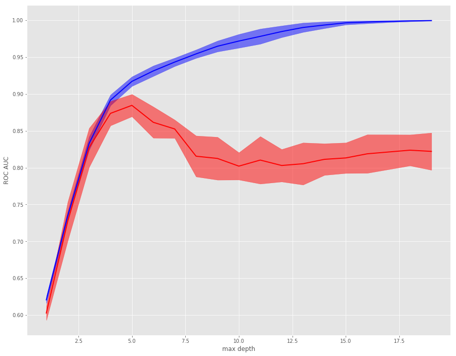

```python
train_score_mean = train_scores.mean(axis=1)
train_score_std = train_scores.std(axis=1)
valid_scores_mean = valid_scores.mean(axis=1)
valid_scores_std = valid_scores.std(axis=1)

plt.fill_between(range(1,20), train_score_mean-train_score_std, train_score_mean+train_score_std, color='b',
                 interpolate=True, alpha=0.5,)
plt.fill_between(range(1,20), valid_scores_mean-valid_scores_std, valid_scores_mean+valid_scores_std, color='r',
                 interpolate=True, alpha=0.5)

plt.plot(range(1,20), train_score_mean, c='b', lw=2)
plt.plot(range(1,20), valid_scores_mean, c='r', lw=2)

plt.xlabel('max depth')
plt.ylabel('ROC AUC')
```

## Подбор всех гиперпараметров

Обычно подбирают гиперпараметры целыми группами. Есть несколько способов это делать

- Полный перебор (Grid Search) - явно задаются все возможные значения параметров. Далее перебираются все возможные комбинации этих параметров
- Случайный перебор (Random Search) - для некоотрых параметров задается распределение через функцию распределения. Задается количество случайных комбинаций, которых требуется перебрать.

[figure not shown]

```python
from scipy.stats import randint as randint
from scipy.stats import uniform

try:
    from sklearn.model_selection import GridSearchCV
    from sklearn.model_selection import RandomizedSearchCV
    from sklearn.model_selection import StratifiedKFold
except ImportError:
    from sklearn.cross_validation import GridSearchCV
    from sklearn.cross_validation import RandomizedSearchCV
    from sklearn.cross_validation import StratifiedKFold


RND_SEED = 123
```

```python
param_grid = {
    'criterion': ['gini', 'entropy'],
    'max_depth': randint(2, 8),
    'min_samples_leaf': randint(5, 10),
    'class_weight': [None, 'balanced']}

cv = StratifiedKFold(n_splits=5, random_state=123, shuffle=True)

model = DecisionTreeClassifier(random_state=123)
random_search = RandomizedSearchCV(model, param_distributions=param_grid, n_iter=200, n_jobs=-1,
                                   cv=cv, scoring='roc_auc', random_state=123)

random_search.fit(X, y)
```

```
RandomizedSearchCV(cv=StratifiedKFold(n_splits=5, random_state=123, shuffle=True),
          error_score='raise-deprecating',
          estimator=DecisionTreeClassifier(class_weight=None, criterion='gini', max_depth=None,
            max_features=None, max_leaf_nodes=None,
            min_impurity_decrease=0.0, min_impurity_split=None,
            min_samples_leaf=1, min_samples_split=2,
            min_weight_fraction_leaf=0.0, presort=False, random_state=123,
            splitter='best'),
          fit_params=None, iid='warn', n_iter=200, n_jobs=-1,
          param_distributions={'criterion': ['gini', 'entropy'], 'max_depth': <scipy.stats._distn_infrastructure.rv_frozen object at 0x000000000BBE9C50>, 'min_samples_leaf': <scipy.stats._distn_infrastructure.rv_frozen object at 0x000000000BC532B0>, 'class_weight': [None, 'balanced']},
          pre_dispatch='2*n_jobs', random_state=123, refit=True,
          return_train_score='warn', scoring='roc_auc', verbose=0)
```

```python
random_search.best_params_
```

```
{'class_weight': None,
 'criterion': 'gini',
 'max_depth': 5,
 'min_samples_leaf': 6}
```

```python
random_search.best_score_
```

```
0.8981263586885004
```

```python
best_model = random_search.best_estimator_;
best_model
```

```
DecisionTreeClassifier(class_weight=None, criterion='gini', max_depth=5,
            max_features=None, max_leaf_nodes=None,
            min_impurity_decrease=0.0, min_impurity_split=None,
            min_samples_leaf=6, min_samples_split=2,
            min_weight_fraction_leaf=0.0, presort=False, random_state=123,
            splitter='best')
```

## Важность признаков

Возьмем лучшую модель и выведем важность признаков

```python
model = random_search.best_estimator_
imp = model.feature_importances_
```

Каждое число соответствует важности признака, который подавался на вход

Для каждого признака (с названием) получите его значение важности

```python
pd.Series(index=df_preproc.columns[:-1], data = imp).sort_values()
```

```
Account Length    0.000000
Intl Charge       0.000000
Day Calls         0.000000
Eve Calls         0.000000
VMail Message     0.000000
Night Calls       0.000576
Night Charge      0.007561
Night Mins        0.008289
Eve Mins          0.010351
VMail Plan        0.062381
Intl Calls        0.089930
Int'l Plan        0.105918
Intl Mins         0.117556
Eve Charge        0.119162
Day Charge        0.125284
CustServ Calls    0.154743
Day Mins          0.198248
dtype: float64
```